# Corpus Analysis and Visualization

Wouter van Atteveldt  
VU-HPC, 2017-11-05

### Course Overview

10:30 - 12:00

- Recap: Frequency Based Analysis and the DTM
- Dictionary Analysis with AmCAT and R

13:30 - 15:00

- *Simple Natural Language Processing*
- Corpus Analysis and Visualization
- Topic Modeling and Visualization

15:15 - 17:00

- Sentiment Analysis with dictionaries
- Sentiment Analysis with proximity

### Simple NLP

- Preprocess documents to get more information
- Relatively fast and accurate
  - Lemmatizing
  - Part-of-Speech (POS) tagging
  - Named Entity Recognition
- Unfortunately, not within R

### NLPipe + nlpiper

- nlpipe: simple NLP processing based on stanford corenlp, others

```bash
docker run --name corenlp -dp 9000:9000 chilland/corenlp-docker

docker run --name nlpipe --link corenlp:corenlp -e "CORENLP_HOST=http://corenlp:9000" -dp 5001:5001 vanatteveldt/nlpipe
```

```r
devtools::install_github("vanatteveldt/nlpiper")
```

```r
library(nlpiper)
process("test_upper", "test")
```

```
0x098f6bcd4621d373cade4e832627b4f6
                            "TEST"
```

### Corenlp POS+lemma+NER

```r
library(nlpiper)
text = "Donald trump was elected president of the United States"
process("corenlp_lemmatize", text, format="csv")
```

### NLPiper and US elections

- You can lemmatize a set of articles or AmCAT set directly
- But that can take a while..
- Download tokens for US elections:

```r
# choose one:
download.file("http://i.amcat.nl/tokens.rds", "tokens.rds")
download.file("http://i.amcat.nl/tokens_full.rds", "tokens.rds")
download.file("http://i.amcat.nl/tokens_sample.rds", "tokens.rds")
```

```r
meta = readRDS("meta.rds")
tokens = readRDS("tokens.rds")
head(tokens)
```

|  | id | sentence | offset | word | lemma | POS | POS1 | ner |
| --- | --- | --- | --- | --- | --- | --- | --- | --- |
| 2 | 160816860 | 1 | 2 | Tennis | tennis | NN | N | O |
| 3 | 160816860 | 1 | 9 | Trailblazer | trailblazer | NN | N | O |
| 4 | 160816860 | 1 | 21 | Leads | lead | VBZ | V | O |
| 6 | 160816860 | 1 | 31 | Charge | Charge | NNP | R | O |
| 8 | 160816860 | 1 | 42 | Women | Women | NNP | R | O |
| 10 | 160816860 | 1 | 50 | Soccer | Soccer | NNP | R | O |

## Corpus Analysis

### Corpus Analysis

- Exploratory Analysis
- Term statistics
- Corpus comparison

The corpustools package

- Useful functions for corpus analysis
- Works on token list rather than dfm/dtm
  - preserves word order

```r
install.packages("corpustools")
```

### Create TCorpus from tokens

```r
library(corpustools)
tc = tokens_to_tcorpus(tokens, "id", sent_i_col = "sentence", )
tc_nouns = tc$subset(POS1=="N", copy = T)

dfm = tc$dtm('lemma', form = 'quanteda_dfm')
```

### Corpus Comparison

```r
pre = subset(meta, medium == "The New York Times" & date < "2016-08-01")
post = subset(meta, medium == "The New York Times" & date >= "2016-08-01")

tc1 = tokens_to_tcorpus(subset(tokens, id %in% pre$id & POS1 == "G"), "id", sent_i_col = "sentence")
tc2 = tokens_to_tcorpus(subset(tokens, id %in% post$id & POS1 == "G"), "id", sent_i_col = "sentence")

cmp = tc1$compare_corpus(tc2, feature = 'lemma')
cmp = plyr::arrange(cmp, -chi2)
head(cmp)
```

| feature | freq.x | freq.y | freq | p.x | p.y | ratio | chi2 |
| --- | --- | --- | --- | --- | --- | --- | --- |
| primary | 2562 | 627 | 3189 | 0.0063271 | 0.0022859 | 2.7679110 | 568.5031 |
| presumptive | 749 | 5 | 754 | 0.0018499 | 0.0000186 | 99.5090224 | 493.4279 |
| musical | 1272 | 412 | 1684 | 0.0031415 | 0.0015022 | 2.0912766 | 176.4415 |
| sexual | 364 | 579 | 943 | 0.0008991 | 0.0021109 | 0.4259513 | 174.3048 |
| medical | 210 | 395 | 605 | 0.0005188 | 0.0014402 | 0.3602565 | 156.8345 |
| nominating | 320 | 35 | 355 | 0.0007905 | 0.0001279 | 6.1783342 | 136.9933 |

## Visualization

### Visualization

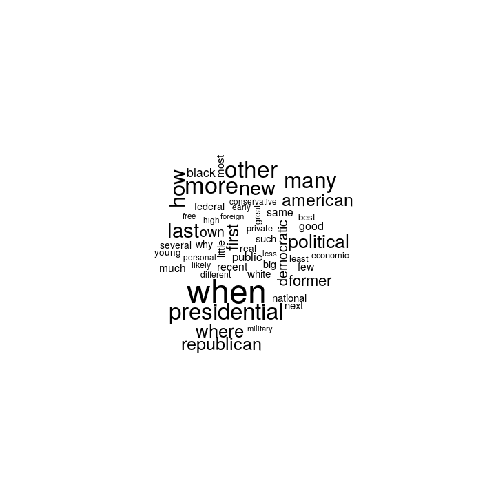

```r
library(quanteda)
dfm = tc2$dtm('lemma', form='quanteda_dfm')
textplot_wordcloud(dfm, max.words = 50, scale = c(4, 0.5))
```

### Beyond (stupid) word clouds

- Word clouds waste most information
- `corpustools::plotWords`
  - specify x, y, colour, size, etc.
- Use any analytics you have to determine characteristics
- See also http://vanatteveldt.com/lse-text-visualization/

### Visualizing comparisons

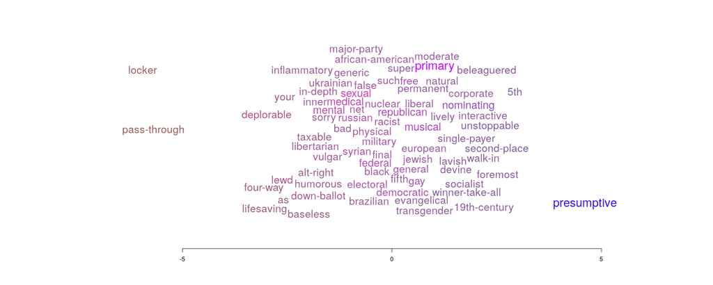

```r
library(scales)
h = rescale(log(cmp$ratio), c(1, .6666))
s = rescale(sqrt(cmp$chi2), c(.25,1))
cmp$col = hsv(h, s, .33 + .67*s)
with(head(cmp, 75), plot_words(x=log(ratio), words=feature, wordfreq=chi2, random.y = T, col=col, scale=1))
```

### Visualizing over time

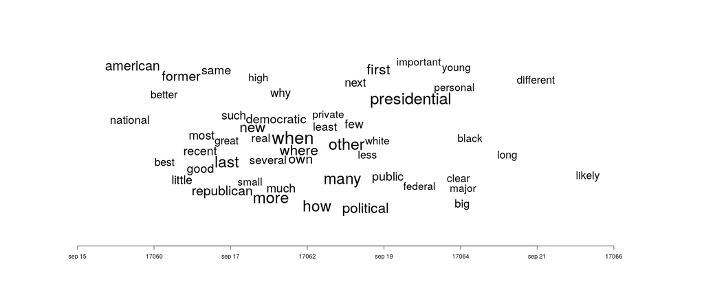

```r
wordfreqs = tidytext::tidy(dfm)
wordfreqs = merge(meta, wordfreqs, by.x="id", by.y="document")
dates = aggregate(wordfreqs["date"], by=wordfreqs["term"], FUN=mean)
freqs = as.data.frame(table(wordfreqs$term))
terms = merge(dates, freqs, by.x="term", by.y="Var1")
terms = plyr::arrange(terms, -Freq)
with(head(terms, 50), plot_words(words=term, x=date, wordfreq = Freq))
axis(1)
```

## Topic Modeling

### Topic Models

### Topic Models

```r
dtm = tc2$dtm(feature='lemma') # from tcorpus
# or: dtm = convert(dfm, to="topicmodels") # from quanteda

set.seed(1234)
library(topicmodels)
m = LDA(dtm, k = 10, method = "Gibbs", control = list(iter = 100, alpha=.1))
head(terms(m, 10))
```

| Topic 1 | Topic 2 | Topic 3 | Topic 4 | Topic 5 | Topic 6 | Topic 7 | Topic 8 | Topic 9 | Topic 10 |
| --- | --- | --- | --- | --- | --- | --- | --- | --- | --- |
| black | when | economic | new | more | when | republican | new | american | how |
| white | how | more | musical | federal | presidential | presidential | free | military | when |
| where | first | last | when | other | former | democratic | more | nuclear | other |
| when | best | new | young | when | last | political | other | foreign | real |
| racial | own | other | novel | many | public | when | where | russian | many |
| african-american | last | many | funny | last | political | many | how | national | more |

Visualizing Topic Models: LDAvis

```r
library(LDAvis)
dtm = dtm[slam::row_sums(dtm) > 0, ]
phi <- posterior(m)$terms %>% as.matrix
theta <- posterior(m)$topics %>% as.matrix
vocab <- colnames(phi)
doc.length = slam::row_sums(dtm)
term.freq = slam::col_sums(dtm)[match(vocab, colnames(dtm))]
json =  createJSON(phi = phi, theta = theta,
             vocab = vocab,
             doc.length = doc.length,
             term.frequency = term.freq)
LDAvis::serVis(json)
```

### Visualizing Topic Models: heat map

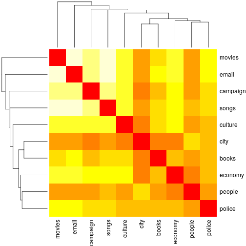

```r
topics = c("books", "police", "culture", "city", "campaign", "movies", "email", "people", "songs", "economy" )
cm = cor(t(m@beta))
colnames(cm) = rownames(cm) = topics
diag(cm) = 0
heatmap(cm, symm = T)
```

### Visualizing Topic Models: word clouds

```r
compare.topics <- function(m, cmp_topics) {
  docs = factor(m@wordassignments$i, labels=m@documents)
  terms = factor(m@wordassignments$j, labels=m@terms)
  assignments = data.frame(doc=docs, term=terms, freq=m@wordassignments$v)
  terms = dcast(assignments, term ~ freq, value.var = "doc", fun.aggregate = length)
  terms = terms[, c(1, cmp_topics+1)]
  terms$freq = rowSums(terms[-1])
  terms = terms[terms$freq > 0,]
  terms$prop = terms[[2]] / terms$freq
  terms$col = hsv(rescale(terms$prop, c(1, .6666)), .5, .5)
  terms[order(-terms$freq), ]
}
```

### Visualizing Topic Models: word clouds

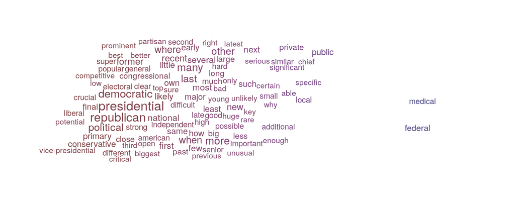

```r
terms = compare.topics(m, match(c("campaign", "email"), topics))
with(head(terms, 100), plot_words(x=prop, wordfreq = freq, words = term, col=col, xaxt="none", random.y = T, scale=2))
```

### Analysing Topic Models

```r
tpd = posterior(m)$topics
colnames(tpd) = topics
tpd = merge(meta, tpd, by.x="id", by.y="row.names")
head(tpd)
```

| id | date | medium | year | month | week | books | police | culture | city | campaign | movies | email | people | songs | economy |
| --- | --- | --- | --- | --- | --- | --- | --- | --- | --- | --- | --- | --- | --- | --- | --- |
| 171933084 | 2016-08-04 | The New York Times | 2016-01-01 | 2016-08-01 | 2016-08-01 | 0.0200000 | 0.0200000 | 0.0200000 | 0.0200000 | 0.0200000 | 0.0200000 | 0.0200000 | 0.2200000 | 0.0200000 | 0.6200000 |
| 171933085 | 2016-08-04 | The New York Times | 2016-01-01 | 2016-08-01 | 2016-08-01 | 0.0250000 | 0.0250000 | 0.0250000 | 0.0250000 | 0.0250000 | 0.0250000 | 0.0250000 | 0.0250000 | 0.7750000 | 0.0250000 |
| 171933086 | 2016-08-04 | The New York Times | 2016-01-01 | 2016-08-01 | 2016-08-01 | 0.0021739 | 0.0673913 | 0.0021739 | 0.0021739 | 0.0021739 | 0.0891304 | 0.8282609 | 0.0021739 | 0.0021739 | 0.0021739 |
| 171933087 | 2016-08-04 | The New York Times | 2016-01-01 | 2016-08-01 | 2016-08-01 | 0.8875000 | 0.0125000 | 0.0125000 | 0.0125000 | 0.0125000 | 0.0125000 | 0.0125000 | 0.0125000 | 0.0125000 | 0.0125000 |
| 171933089 | 2016-08-04 | The New York Times | 2016-01-01 | 2016-08-01 | 2016-08-01 | 0.0008333 | 0.4591667 | 0.0008333 | 0.1091667 | 0.0008333 | 0.0008333 | 0.0008333 | 0.0008333 | 0.4175000 | 0.0091667 |
| 171933090 | 2016-08-04 | The New York Times | 2016-01-01 | 2016-08-01 | 2016-08-01 | 0.0024390 | 0.0024390 | 0.1000000 | 0.0024390 | 0.0024390 | 0.0024390 | 0.0024390 | 0.0268293 | 0.8560976 | 0.0024390 |

## Hands-on session II

- Corpus analysis of Election campaign
  - (or your own data…)
- Which words, adjectives, verbs, etc are frequent?
- How do they differ over time, by medium, subcorpus
- What topics can we find?
- Can we visualize topics, contrasts, etc.